# The Scope and Skill Sets of Malaria Models

How do models represent the observable world?

October 27, 2023

`~/ModelBuilding/Skill-Set.Rmd`

HUB – Roadmap – Library – Model Building

## $\odot$

**Abstract** – Mechanistic models for malaria epidemiology, transmission dynamics, and control are designed to represent a reality that we know about through an observational process. These mechanistic models are formulated from a set of quantitative and qualitative observations, usually combining mathematics, statistics, and basic logic. The models are all approximating reality, which is extremely complex and messy, with some degree of fidelity. We engage in model building as a way of understanding reality through analysis that can help us to identify relevant detail and make good decisions. One of the questions we must grapple with is what level of detail is required of models that are used in policy?

As we compare mechanistic models to each other, and as we challenge models with data, we note some important differences or limitations in how much various models can do for us. Each model represents the *state* of a system to varying degrees of detail and abstraction. For example, models of malaria epidemiology are generically defined by a set of state variables, represented by $\cal X$, with dynamics,

$$d {\cal X}/dt = F_{\cal X} ({\cal
X}).$$

If we want to fit models to data, we embed our mechanistic model in a state space modeling framework by defining an observational process model that translates the states of the mechanistic model onto a set of metrics through an observational process model, $O$, where:

$$O({\cal X}, \ldots) \rightarrow \vec
X.$$

We define the **scope** of a state space model as the full set of defined observable quantities – it is represented by the vector $\vec X.$

In discussions of mechanistic models, we can simply discuss the *states* of the system, but in a state space modeling framework, we need to be more careful about using the term “states”:

- In a state-space modeling framework, the variables in $\cal X$ are called *latent states.* Within the universe defined by the model, they are *putatively true,* but they can’t be observed directly and (with the exception of making ourselves omniscient when we conduct simulation studies) are thus only knowable through an observational process.
- The observational process model translates the latent states into *observable states*, $\vec X$.

As we compare the mechanistic models that we use within our fully-defined state-space models, we need to be able to discuss the capabilities of the mechanistic models in relation to the scope of a state-space model.

> The *skill set* of a mechanistic model is defined as the set of observable quantities that are naturally represented by the latent states such that they can be computed without requiring extraneous information.

In some models, some observable quantities, or observable *states* can not be computed naturally from the latent variables without adding substantial additional information. If we have defined a minimal *scope* for our study, it might be possible to augment the observational process model with other information to define a useful function $O({\cal X}, \ldots).$

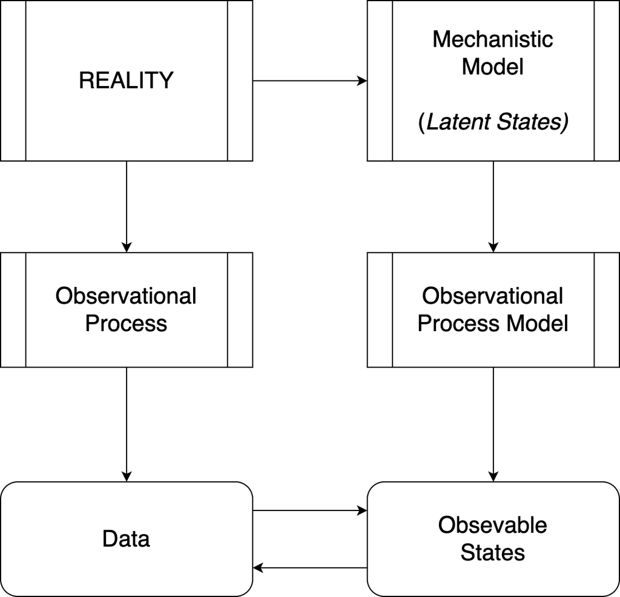

## $\dagger$

**Contributors**

- David L. Smith
- John M. Henry
- Austin R. Carter.

**References**